# Explaining the Data Set

The life expectancy dataset is a collection of data from various countries around the world, providing information on factors that may influence life expectancy. The dataset consists of 22 variables, including the country, year, life expectancy, GDP, population, and schooling. The data spans over the years from 2000 to 2015. The data has been collected from a variety of sources, including the World Health Organization (WHO), the United Nations (UN), and the World Bank (WB). The dataset contains data from 193 countries around the world, making it a comprehensive source of information on global health trends. The dataset is available in CSV format and is easily accessible for analysis. The dataset is used for studying the impact of socioeconomic factors on health outcomes, such as life expectancy. The dataset provides an opportunity to study the relationship between various factors, such as income, education, and health. The dataset also provides insights into the disparities in health outcomes between countries and regions. The dataset has been pre-processed and cleaned to ensure that the data is consistent and accurate.

The world income inequality dataset has multiple tables containing different observations of each countries over the span of around 50 years. dataset "income-share-of-the-top-10-pip" consists of Country, Code, Year, Share of the richest decile in total income or expenditure. dataset "income-shares-by-quintile" consists of Country, Code, Year, Share of each quintile in the total income or expenditure. The dataset has been collected from a source cited in the citations section. The dataset is easily accessible for analysis. It is used for studying the inequalities in countries over the years by comparing their richest and poorest quintiles. The dataset has been already pre-processed and cleaned to ensure that data is consistent and accurate.

# Objective

**The primary objective is to find disparity in life expectancy of among countries based on their status, i.e. they are developed or developing.**

**Investigating the dependency of life expectancy on various independent parameters like Schooling , GDP etc.**

In this Project we analyze the life expectancy data of different countries and explore various factors that affect the life expectancy of countries. In this project various data analysis techniques such as hypothesis testing, time series forecasting, and clustering have been used to gain insights and make informed decisions based on the data.

The project also aims to create interactive visualizations to better communicate the findings and provide a better understanding of the data.

# Analysing and Exploring data

```python
import pandas as pd
import numpy as np
import matplotlib.pyplot as plt
import seaborn as sns
```

```python
df = pd.read_csv('Life Expectancy Data.csv')
```

```python
df
```

|  | Country | Year | Status | Life expectancy | Adult Mortality | infant deaths | Alcohol | percentage expenditure | Hepatitis B | Measles | ... | Polio | Total expenditure | Diphtheria | HIV/AIDS | GDP | Population | thinness 1-19 years | thinness 5-9 years | Income composition of resources | Schooling |
| --- | --- | --- | --- | --- | --- | --- | --- | --- | --- | --- | --- | --- | --- | --- | --- | --- | --- | --- | --- | --- | --- |
| 0 | Afghanistan | 2015 | Developing | 65.0 | 263.0 | 62 | 0.01 | 71.279624 | 65.0 | 1154 | ... | 6.0 | 8.16 | 65.0 | 0.1 | 584.259210 | 33736494.0 | 17.2 | 17.3 | 0.479 | 10.1 |
| 1 | Afghanistan | 2014 | Developing | 59.9 | 271.0 | 64 | 0.01 | 73.523582 | 62.0 | 492 | ... | 58.0 | 8.18 | 62.0 | 0.1 | 612.696514 | 327582.0 | 17.5 | 17.5 | 0.476 | 10.0 |
| 2 | Afghanistan | 2013 | Developing | 59.9 | 268.0 | 66 | 0.01 | 73.219243 | 64.0 | 430 | ... | 62.0 | 8.13 | 64.0 | 0.1 | 631.744976 | 31731688.0 | 17.7 | 17.7 | 0.470 | 9.9 |
| 3 | Afghanistan | 2012 | Developing | 59.5 | 272.0 | 69 | 0.01 | 78.184215 | 67.0 | 2787 | ... | 67.0 | 8.52 | 67.0 | 0.1 | 669.959000 | 3696958.0 | 17.9 | 18.0 | 0.463 | 9.8 |
| 4 | Afghanistan | 2011 | Developing | 59.2 | 275.0 | 71 | 0.01 | 7.097109 | 68.0 | 3013 | ... | 68.0 | 7.87 | 68.0 | 0.1 | 63.537231 | 2978599.0 | 18.2 | 18.2 | 0.454 | 9.5 |
| ... | ... | ... | ... | ... | ... | ... | ... | ... | ... | ... | ... | ... | ... | ... | ... | ... | ... | ... | ... | ... | ... |
| 2933 | Zimbabwe | 2004 | Developing | 44.3 | 723.0 | 27 | 4.36 | 0.000000 | 68.0 | 31 | ... | 67.0 | 7.13 | 65.0 | 33.6 | 454.366654 | 12777511.0 | 9.4 | 9.4 | 0.407 | 9.2 |
| 2934 | Zimbabwe | 2003 | Developing | 44.5 | 715.0 | 26 | 4.06 | 0.000000 | 7.0 | 998 | ... | 7.0 | 6.52 | 68.0 | 36.7 | 453.351155 | 12633897.0 | 9.8 | 9.9 | 0.418 | 9.5 |
| 2935 | Zimbabwe | 2002 | Developing | 44.8 | 73.0 | 25 | 4.43 | 0.000000 | 73.0 | 304 | ... | 73.0 | 6.53 | 71.0 | 39.8 | 57.348340 | 125525.0 | 1.2 | 1.3 | 0.427 | 10.0 |
| 2936 | Zimbabwe | 2001 | Developing | 45.3 | 686.0 | 25 | 1.72 | 0.000000 | 76.0 | 529 | ... | 76.0 | 6.16 | 75.0 | 42.1 | 548.587312 | 12366165.0 | 1.6 | 1.7 | 0.427 | 9.8 |
| 2937 | Zimbabwe | 2000 | Developing | 46.0 | 665.0 | 24 | 1.68 | 0.000000 | 79.0 | 1483 | ... | 78.0 | 7.10 | 78.0 | 43.5 | 547.358878 | 12222251.0 | 11.0 | 11.2 | 0.434 | 9.8 |

2938 rows × 22 columns

```python
df.head()
df.info()
df.describe()
```

```
<class 'pandas.core.frame.DataFrame'>
RangeIndex: 2938 entries, 0 to 2937
Data columns (total 22 columns):
 #   Column                           Non-Null Count  Dtype
---  ------                           --------------  -----
 0   Country                          2938 non-null   object
 1   Year                             2938 non-null   int64
 2   Status                           2938 non-null   object
 3   Life expectancy                  2928 non-null   float64
 4   Adult Mortality                  2928 non-null   float64
 5   infant deaths                    2938 non-null   int64
 6   Alcohol                          2744 non-null   float64
 7   percentage expenditure           2938 non-null   float64
 8   Hepatitis B                      2385 non-null   float64
 9   Measles                          2938 non-null   int64
 10   BMI                             2904 non-null   float64
 11  under-five deaths                2938 non-null   int64
 12  Polio                            2919 non-null   float64
 13  Total expenditure                2712 non-null   float64
 14  Diphtheria                       2919 non-null   float64
 15   HIV/AIDS                        2938 non-null   float64
 16  GDP                              2490 non-null   float64
 17  Population                       2286 non-null   float64
 18   thinness  1-19 years            2904 non-null   float64
 19   thinness 5-9 years              2904 non-null   float64
 20  Income composition of resources  2771 non-null   float64
 21  Schooling                        2775 non-null   float64
dtypes: float64(16), int64(4), object(2)
memory usage: 505.1+ KB
```

|  | Year | Life expectancy | Adult Mortality | infant deaths | Alcohol | percentage expenditure | Hepatitis B | Measles | BMI | under-five deaths | Polio | Total expenditure | Diphtheria | HIV/AIDS | GDP | Population | thinness 1-19 years | thinness 5-9 years | Income composition of resources | Schooling |
| --- | --- | --- | --- | --- | --- | --- | --- | --- | --- | --- | --- | --- | --- | --- | --- | --- | --- | --- | --- | --- |
| count | 2938.000000 | 2928.000000 | 2928.000000 | 2938.000000 | 2744.000000 | 2938.000000 | 2385.000000 | 2938.000000 | 2904.000000 | 2938.000000 | 2919.000000 | 2712.00000 | 2919.000000 | 2938.000000 | 2490.000000 | 2.286000e+03 | 2904.000000 | 2904.000000 | 2771.000000 | 2775.000000 |
| mean | 2007.518720 | 69.224932 | 164.796448 | 30.303948 | 4.602861 | 738.251295 | 80.940461 | 2419.592240 | 38.321247 | 42.035739 | 82.550188 | 5.93819 | 82.324084 | 1.742103 | 7483.158469 | 1.275338e+07 | 4.839704 | 4.870317 | 0.627551 | 11.992793 |
| std | 4.613841 | 9.523867 | 124.292079 | 117.926501 | 4.052413 | 1987.914858 | 25.070016 | 11467.272489 | 20.044034 | 160.445548 | 23.428046 | 2.49832 | 23.716912 | 5.077785 | 14270.169342 | 6.101210e+07 | 4.420195 | 4.508882 | 0.210904 | 3.358920 |
| min | 2000.000000 | 36.300000 | 1.000000 | 0.000000 | 0.010000 | 0.000000 | 1.000000 | 0.000000 | 1.000000 | 0.000000 | 3.000000 | 0.37000 | 2.000000 | 0.100000 | 1.681350 | 3.400000e+01 | 0.100000 | 0.100000 | 0.000000 | 0.000000 |
| 25% | 2004.000000 | 63.100000 | 74.000000 | 0.000000 | 0.877500 | 4.685343 | 77.000000 | 0.000000 | 19.300000 | 0.000000 | 78.000000 | 4.26000 | 78.000000 | 0.100000 | 463.935626 | 1.957932e+05 | 1.600000 | 1.500000 | 0.493000 | 10.100000 |
| 50% | 2008.000000 | 72.100000 | 144.000000 | 3.000000 | 3.755000 | 64.912906 | 92.000000 | 17.000000 | 43.500000 | 4.000000 | 93.000000 | 5.75500 | 93.000000 | 0.100000 | 1766.947595 | 1.386542e+06 | 3.300000 | 3.300000 | 0.677000 | 12.300000 |
| 75% | 2012.000000 | 75.700000 | 228.000000 | 22.000000 | 7.702500 | 441.534144 | 97.000000 | 360.250000 | 56.200000 | 28.000000 | 97.000000 | 7.49250 | 97.000000 | 0.800000 | 5910.806335 | 7.420359e+06 | 7.200000 | 7.200000 | 0.779000 | 14.300000 |
| max | 2015.000000 | 89.000000 | 723.000000 | 1800.000000 | 17.870000 | 19479.911610 | 99.000000 | 212183.000000 | 87.300000 | 2500.000000 | 99.000000 | 17.60000 | 99.000000 | 50.600000 | 119172.741800 | 1.293859e+09 | 27.700000 | 28.600000 | 0.948000 | 20.700000 |

```python
df = df.fillna(df.mean())
```

```
C:\Users\Unlock me\AppData\Local\Temp\ipykernel_50804\114435927.py:1: FutureWarning:

The default value of numeric_only in DataFrame.mean is deprecated. In a future version, it will default to False. In addition, specifying 'numeric_only=None' is deprecated. Select only valid columns or specify the value of numeric_only to silence this warning.
```

# Correlation Matrix and Heatmap

```
C:\Users\Unlock me\AppData\Local\Temp\ipykernel_50804\570970446.py:1: FutureWarning:

The default value of numeric_only in DataFrame.corr is deprecated. In a future version, it will default to False. Select only valid columns or specify the value of numeric_only to silence this warning.
```

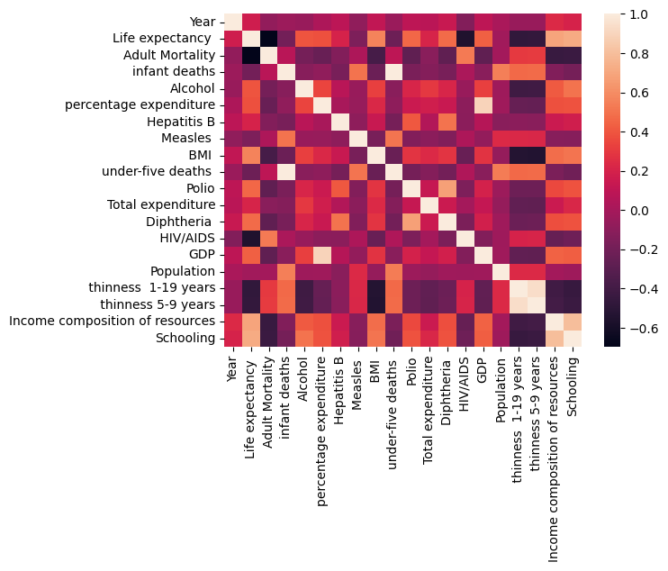

```python
corr_matrix = df.corr()
sns.heatmap(corr_matrix)
plt.show()
```

# Distribution of life expectancy by status

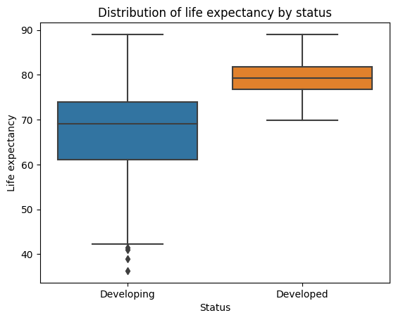

```python
import seaborn as sns

sns.boxplot(x='Status', y='Life expectancy ', data=df)
plt.xlabel('Status')
plt.ylabel('Life expectancy')
plt.title('Distribution of life expectancy by status')
plt.show()
```

**Interpretation**: The box plot shows that developed countries have a higher median life expectancy than developing countries, with less variability in the distribution. The box plot also shows that developing countries have a wider range of life expectancies, with some countries having very low life expectancy.

## Countries with least Life Expectancy over the years

```python
import plotly.graph_objs as go
def get_top6_countries(df, year):
    df_year = df[df['Year'] == year]
    return df_year.nsmallest(6, 'Life expectancy ')

years = df['Year'].unique().tolist()


fig = go.Figure()

df_initial = get_top6_countries(df, years[0])
fig.add_trace(go.Bar(x=df_initial['Country'], y=df_initial['Life expectancy '], name=str(years[0])))

fig.update_layout(title='Countries with the least Life Expectancy', xaxis_title='Country', yaxis_title='Life Expectancy (years)',
                  xaxis={'type': 'category'}, yaxis_range=[0, 100], barmode='group')

slider = dict(
    active=0,
    pad={"t": 50},
    steps=[],
)


for year in years:
    df_top6 = get_top6_countries(df, year)
    countries = df_top6['Country'].tolist()
    slider['steps'].append(dict(label=str(year), method="update", args=[{"x": [countries], "y": [df_top6['Life expectancy '].tolist()], "visible": [True]},
                                                                          {"title": str(year)}]))


fig.update_layout(sliders=[slider])

# Display the figure
fig.show()
```

## Countries with highest life expectancies over the years

```python
import plotly.graph_objs as go
def get_top6_countries(df, year):
    df_year = df[df['Year'] == year]
    return df_year.nlargest(6, 'Life expectancy ')

years = df['Year'].unique().tolist()


fig = go.Figure()

df_initial = get_top6_countries(df, years[0])
fig.add_trace(go.Bar(x=df_initial['Country'], y=df_initial['Life expectancy '], name=str(years[0])))

fig.update_layout(title='Countries with the  Highest Life Expectancy', xaxis_title='Country', yaxis_title='Life Expectancy (years)',
                  xaxis={'type': 'category'}, yaxis_range=[0, 100], barmode='group')

slider = dict(
    active=0,
    pad={"t": 50},
    steps=[],
)


for year in years:
    df_top6 = get_top6_countries(df, year)
    countries = df_top6['Country'].tolist()
    slider['steps'].append(dict(label=str(year), method="update", args=[{"x": [countries], "y": [df_top6['Life expectancy '].tolist()], "visible": [True]},
                                                                          {"title": str(year)}]))


fig.update_layout(sliders=[slider])

# Display the figure
fig.show()
```

## Life Expectancy and Income composition of resources

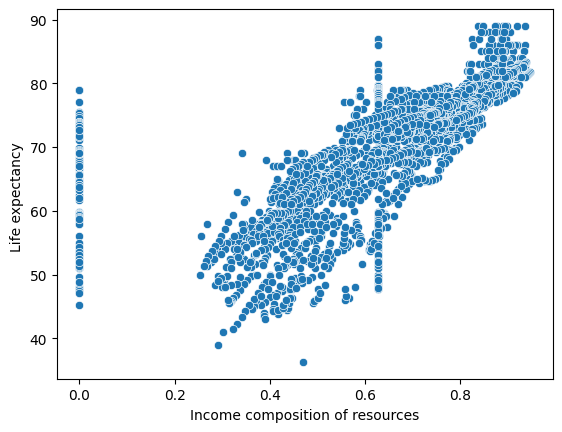

```python
import scipy as sp

sns.scatterplot(x='Income composition of resources', y='Life expectancy ', data=df)
```

**Interpretation**: This plot shows the relationship between life expectancy and income composition of resources. It appears that there is a strong positive correlation between the two variables, indicating that countries with higher income composition of resources tend to have higher life expectancies.

```python
import plotly.graph_objs as go
import plotly.tools as tls
import plotly.offline as py
```

```python
import plotly.express as px

fig = px.choropleth(df, locations='Country', locationmode='country names', color='Life expectancy ',
                    hover_name='Country', animation_frame='Year', range_color=[20, 90])
fig.update_layout(title_text='World Life Expectancy over the Years (2000-2015)')
fig.show()
```

```python
df_india = df[df['Country'] == 'India']

# Create interactive line graph
fig = px.line(df_india, x='Year', y='Life expectancy ',
              title='Life Expectancy in India (Year-wise)',
              hover_data={'Life expectancy ': ':.1f'})
fig.update_layout(xaxis_title='Year', yaxis_title='Life Expectancy')
fig.update_traces(mode='markers+lines', marker=dict(size=8, line=dict(width=2)))
fig.show()
```

```python
import plotly.graph_objs as go

countries = ['India', 'China', 'United States of America', 'France', 'Japan', 'United Kingdom of Great Britain and Northern Ireland']

traces = []

for country in countries:
    df_country = df[df['Country'] == country]
    trace = go.Scatter(x=df_country['Year'], y=df_country['Life expectancy '], name=country, marker=dict(size=8))
    traces.append(trace)

layout = go.Layout(
    title='Life Expectancy of Selected Countries',
    xaxis=dict(
        title='Year',
        ticklen=5,
        zeroline=False,
        gridwidth=2,
    ),
    yaxis=dict(
        title='Life Expectancy',
        ticklen=5,
        gridwidth=2,
    ),
    showlegend=True,
    hovermode='closest',
)

fig = go.Figure(data=traces, layout=layout)
fig.show()
```

# Hypothesis Testing

**Hypothesis 1:**

**Null hypothesis**: There is no significant difference in life expectancy between developed and developing countries.

**Alternative hypothesis**: There is a significant difference in life expectancy between developed and developing countries.

```python
from scipy.stats import ttest_ind

developed = df[df['Status'] == 'Developed']['Life expectancy ']
developing = df[df['Status'] == 'Developing']['Life expectancy ']

t_stat, p_val = ttest_ind(developed, developing)

print('t-statistic:', t_stat)
print('p-value:', p_val)
```

```
t-statistic: 29.805188781530223
p-value: 9.034938663789684e-171
```

```python
# Significance level
alpha = 0.05

if p_val < alpha:
    print("Reject null hypothesis")
else:
    print("Fail to reject null hypothesis")
```

```
Reject null hypothesis
```

**Interpretation**: We have conducted a two-sample t-test to compare the life expectancy of developed and developing countries. The t-statistic obtained from the test was 29.805, and the p-value was 9.034e-171. We set the significance level (alpha) at 0.05. Since the p-value (9.034e-171) is less than the significance level (0.05), we reject the null hypothesis.

### Finding correleation between columns and Displaying those factors contributing most to the life expectancy in developed and developing countries

[output not shown]

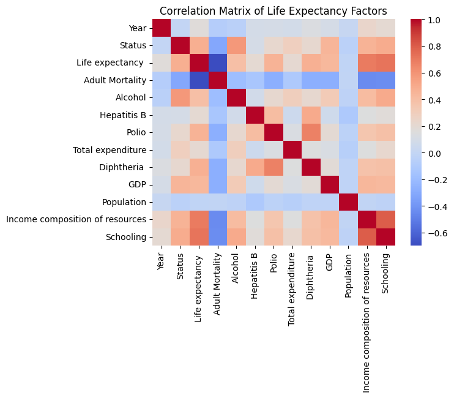

```python
cols = ['Year', 'Status', 'Life expectancy ', 'Adult Mortality', 'Alcohol','Hepatitis B', 'Polio', 'Total expenditure', 'Diphtheria ', 'GDP', 'Population', 'Income composition of resources', 'Schooling']
df1 = df[cols]


df1['Status'] = df1['Status'].apply(lambda x: 1 if x == 'Developed' else 0)


df1.dropna(inplace=True)


corr = df1.corr()

sns.heatmap(corr, cmap='coolwarm')
plt.title('Correlation Matrix of Life Expectancy Factors')
plt.show()
```

```python
developed = df[df['Status'] == 'Developed']
developing = df[df['Status'] == 'Developing']

corr_matrix_developed = developed.corr()


corr_matrix_developing = developing.corr()

corr_developed = corr_matrix_developed['Life expectancy '].sort_values(ascending=False)


corr_developing = corr_matrix_developing['Life expectancy '].sort_values(ascending=False)

print("Top three correlations for developed countries:")
print(corr_developed[1:4])
print("\nTop three correlations for developing countries:")
print(corr_developing[1:4])
```

```
Top three correlations for developed countries:
Income composition of resources    0.473753
GDP                                0.363391
Schooling                          0.351472
Name: Life expectancy , dtype: float64

Top three correlations for developing countries:
Schooling                          0.647412
Income composition of resources    0.610979
 BMI                               0.545419
Name: Life expectancy , dtype: float64
```

```
C:\Users\Unlock me\AppData\Local\Temp\ipykernel_50804\4034041282.py:4: FutureWarning:

The default value of numeric_only in DataFrame.corr is deprecated. In a future version, it will default to False. Select only valid columns or specify the value of numeric_only to silence this warning.

C:\Users\Unlock me\AppData\Local\Temp\ipykernel_50804\4034041282.py:7: FutureWarning:

The default value of numeric_only in DataFrame.corr is deprecated. In a future version, it will default to False. Select only valid columns or specify the value of numeric_only to silence this warning.
```

# Life Expectancy by Country Development Status (Year-wise)

```python
df_grouped = df.groupby(['Year', 'Status'], as_index=False).mean()


fig = go.Figure()


developed_data = df_grouped[df_grouped['Status'] == 'Developed']
fig.add_trace(go.Scatter(x=developed_data['Year'], y=developed_data['Life expectancy '], mode='lines+markers',
                         name='Developed', marker=dict(size=8, line=dict(width=2)),
                         hovertemplate='Year: %{x}<br>Life Expectancy: %{y:.1f}<extra></extra>'))


developing_data = df_grouped[df_grouped['Status'] == 'Developing']
fig.add_trace(go.Scatter(x=developing_data['Year'], y=developing_data['Life expectancy '], mode='lines+markers',
                          name='Developing', marker=dict(size=8, line=dict(width=2)),
                          hovertemplate='Year: %{x}<br>Life Expectancy: %{y:.1f}<extra></extra>'))


fig.update_layout(title_text='Life Expectancy by Country Development Status (Year-wise)',
                  xaxis_title='Year', yaxis_title='Life Expectancy', hovermode='x',
                  legend=dict(x=0, y=1, bgcolor='rgba(255, 255, 255, 0.5)', bordercolor='rgba(0, 0, 0, 0)'),
                  annotations=[go.layout.Annotation(x=year, y=90, xref='x', yref='y', text=str(year), showarrow=True,
                                                     arrowhead=2, arrowsize=1, arrowwidth=1,
                                                     ax=-20, ay=-30, bordercolor='black', borderwidth=2,
                                                     bgcolor='white') for year in range(2000, 2016)])

fig.show()
```

```
C:\Users\Unlock me\AppData\Local\Temp\ipykernel_50804\2480237900.py:1: FutureWarning:

The default value of numeric_only in DataFrameGroupBy.mean is deprecated. In a future version, numeric_only will default to False. Either specify numeric_only or select only columns which should be valid for the function.
```

# Cluster Analysis of Life Expectancy Data

```python
from sklearn.preprocessing import StandardScaler
from sklearn.cluster import KMeans
df_cluster = df[['Country', 'Year', 'Life expectancy ', 'GDP', 'Population', 'Schooling','Income composition of resources']]


scaler = StandardScaler()
df_scaled = scaler.fit_transform(df_cluster.iloc[:, 2:])

kmeans = KMeans(n_clusters=2, random_state=42).fit(df_scaled)


df_cluster['Cluster'] = kmeans.labels_


fig = px.scatter_3d(df_cluster, x='Income composition of resources', y='Schooling', z='Life expectancy ', color='Cluster',
                    hover_name='Country', animation_frame='Year', range_color=[0, 2])
fig.update_layout(title_text='Cluster Analysis of Life Expectancy Data')
fig.show()
```

[output not shown]

**Interpretations:** Based on the scatter plot, it can be observed that there are two distinct clusters of countries based on their life expectancy, income composition of resources, and schooling,GDP. The blue cluster represents countries with high life expectancy, while the purple cluster represents countries with low life expectancy.

It is also worth noting that the countries in the blue cluster generally have a higher income composition of resources and schooling compared to countries in the purple cluster. This suggests that these factors may play a role in determining life expectancy.

Overall, the cluster analysis provides further evidence to support the claim that there is a significant difference in life expectancy between developed and developing countries, as indicated by the distinct clusters of countries with high and low life expectancy.

### **One of the main objective to find the inequality is through economic inequality for each country over the years.**

```python
import plotly.express as px
import pandas as pd
import numpy as np
import plotly.graph_objects as go

# Load data
Eco_df = pd.read_csv('income-shares-by-quintile-pip.csv')

# List of countries
countries = Eco_df['Country'].unique()
```

```python
Eco_df
```

|  | Country | Code | Year | Share of the richest quintile in total income or expenditure | Share of the 4th quintile in total income or expenditure | Share of the 3rd quintile in total income or expenditure | Share of the 2nd quintile in total income or expenditure | Share of the poorest quintile in total income or expenditure |
| --- | --- | --- | --- | --- | --- | --- | --- | --- |
| 0 | Albania | ALB | 1996 | 36.115121 | 23.296956 | 17.734564 | 13.700725 | 9.152633 |
| 1 | Albania | ALB | 2002 | 40.360715 | 22.213014 | 16.492562 | 12.580263 | 8.353446 |
| 2 | Albania | ALB | 2005 | 39.175111 | 22.498552 | 17.025227 | 12.898465 | 8.402645 |
| 3 | Albania | ALB | 2008 | 38.993515 | 22.227811 | 16.836211 | 13.072056 | 8.870407 |
| 4 | Albania | ALB | 2012 | 37.823477 | 22.808756 | 17.340775 | 13.174370 | 8.852622 |
| ... | ... | ... | ... | ... | ... | ... | ... | ... |
| 2117 | Zambia | ZMB | 2006 | 59.468406 | 19.145137 | 11.054804 | 6.786949 | 3.544705 |
| 2118 | Zambia | ZMB | 2010 | 61.050270 | 17.889969 | 10.488170 | 6.761818 | 3.809772 |
| 2119 | Zambia | ZMB | 2015 | 61.267680 | 19.278932 | 10.569799 | 5.999579 | 2.884011 |
| 2120 | Zimbabwe | ZWE | 2011 | 49.664463 | 21.011286 | 14.002204 | 9.497565 | 5.824482 |
| 2121 | Zimbabwe | ZWE | 2017 | 51.111684 | 20.631633 | 13.171137 | 9.121204 | 5.964342 |

2122 rows × 8 columns

```python
# Create a figure which shows share of income by quintile over scrolling the timeline bar.
# X axis is the Year from 1977 to 2019 and Y axis is the % of income or expenditure.
# The figure contains 5 areas for each quintile seperated by lines with different colors.
# The color of the area is the same as the color of the line.
fig = px.area(Eco_df[Eco_df['Country'] == 'India'], x="Year", y=["Share of the richest quintile in total income or expenditure", "Share of the 4th quintile in total income or expenditure", "Share of the 3rd quintile in total income or expenditure", "Share of the 2nd quintile in total income or expenditure", "Share of the poorest quintile in total income or expenditure"], color_discrete_sequence=['#1f77b4', '#ff7f0e', '#2ca02c', '#d62728', '#9467bd'])
fig.update_layout(
    title="Share of income or expenditure by quintile over time in selected country",
    xaxis_title="Year",
    yaxis_title="Share of income or expenditure (%)",
    legend_title="Quintile",
    font=dict(
        family="Courier New, monospace",
        size=18,
        color="RebeccaPurple"
    )
)


# Give an option to select a country from the list
fig.update_layout(
    updatemenus=[
        dict(
            buttons=list([
                dict(
                    args=[{"y": [Eco_df[Eco_df['Country'] == country]['Share of the richest quintile in total income or expenditure'], Eco_df[Eco_df['Country'] == country]['Share of the 4th quintile in total income or expenditure'], Eco_df[Eco_df['Country'] == country]['Share of the 3rd quintile in total income or expenditure'], Eco_df[Eco_df['Country'] == country]['Share of the 2nd quintile in total income or expenditure'], Eco_df[Eco_df['Country'] == country]['Share of the poorest quintile in total income or expenditure']]}],
                    label=country,
                    method="update"
                ) for country in countries
            ]),
            direction="down",
            pad={"r": 10, "t": 10},
            showactive=True,
            x=0.1,
            xanchor="left",
            y=1.1,
            yanchor="top"
        ),
    ],
)

# Add a slider to the figure
fig.update_layout(
    xaxis=dict(
        rangeslider=dict(
            visible=True
        ),
        type="date"
    )
)


# Show the figure
fig.show()
```

# Forecasting Future Life Expectancy of Developed and Developing Countries

```python
import plotly.graph_objs as go
import plotly.offline as pyo
from statsmodels.tsa.arima.model import ARIMA

df1 = df.copy()
df1['Year'] = pd.to_datetime(df1['Year'], format='%Y')

df_dev = df1[df1['Status'] == 'Developed']
df_dev_avg = df_dev.groupby('Year')['Life expectancy '].mean().reset_index()

df_devp = df1[df1['Status'] == 'Developing']
df_devp_avg = df_devp.groupby('Year')['Life expectancy '].mean().reset_index()

model_devp = ARIMA(df_devp_avg['Life expectancy '], order=(1,1,1))
model_devp_fit = model_devp.fit()
forecast_devp = model_devp_fit.forecast(steps=10)


model_dev = ARIMA(df_dev_avg['Life expectancy '], order=(1,1,1))
model_dev_fit = model_dev.fit()
forecast_dev = model_dev_fit.forecast(steps=10)

fig = go.Figure()

fig.add_trace(go.Scatter(x=df_dev_avg['Year'], y=df_dev_avg['Life expectancy '],
                    mode='lines+markers', name='Developed Historical Data'))

fig.add_trace(go.Scatter(x=df_devp_avg['Year'], y=df_devp_avg['Life expectancy '],
                    mode='lines+markers', name='Developing Historical Data'))

fig.add_trace(go.Scatter(x=pd.date_range(start='2016', periods=10, freq='Y'), y=forecast_dev,
                    mode='lines+markers', name='Developed Forecast'))

fig.add_trace(go.Scatter(x=pd.date_range(start='2016', periods=10, freq='Y'), y=forecast_devp,
                    mode='lines+markers', name='Developing Forecast'))

fig.update_layout(title='Life Expectancy Forecast for Developed and Developing Countries',
                   xaxis_title='Year',
                   yaxis_title='Life Expectancy')

fig.update_traces(hoverinfo='text', hovertext=[f'Year: {year}<br>Life Expectancy: {life_expectancy:.2f}'
                                               for year, life_expectancy in zip(df_dev_avg['Year'], df_dev_avg['Life expectancy '])],
                  selector=dict(mode='lines+markers', name='Developed Historical Data'))

fig.update_traces(hoverinfo='text', hovertext=[f'Year: {year}<br>Life Expectancy: {life_expectancy:.2f}'
                                               for year, life_expectancy in zip(df_devp_avg['Year'], df_devp_avg['Life expectancy '])],
                  selector=dict(mode='lines+markers', name='Developing Historical Data'))

fig.update_traces(hoverinfo='text', hovertext=[f'Year: {year}<br>Life Expectancy Forecast: {life_expectancy:.2f}'
                                               for year, life_expectancy in zip(pd.date_range(start='2016', periods=10, freq='Y'), forecast_dev)],
                  selector=dict(mode='lines+markers', name='Developed Forecast'))

fig.update_traces(hoverinfo='text', hovertext=[f'Year: {year}<br>Life Expectancy Forecast: {life_expectancy:.2f}'
                                               for year, life_expectancy in zip(pd.date_range(start='2016', periods=10, freq='Y'), forecast_devp)],
                  selector=dict(mode='lines+markers', name='Developing Forecast'))

pyo.iplot(fig)
```

```
c:\Users\Unlock me\AppData\Local\Programs\Python\Python310\lib\site-packages\statsmodels\tsa\statespace\sarimax.py:966: UserWarning:

Non-stationary starting autoregressive parameters found. Using zeros as starting parameters.

c:\Users\Unlock me\AppData\Local\Programs\Python\Python310\lib\site-packages\statsmodels\base\model.py:604: ConvergenceWarning:

Maximum Likelihood optimization failed to converge. Check mle_retvals
```

**Hypothesis 2:**  
**Null Hypothesis**: There is no significant relationship between life expectancy and GDP, schooling, and income composition.

**Alternative Hypothesis**: There is a significant relationship between life expectancy and GDP, schooling, and income composition.

In this hypothesis testing we will be using **OLS Regression**.

Ordinary Least Squares (OLS) regression is a widely used statistical method for estimating the relationship between a dependent variable and one or more independent variables. The main principle of OLS is to minimize the sum of the squared differences between the observed dependent variable values and the predicted values obtained from the regression model.

```python
import statsmodels.api as sm
X = df[["GDP", "Schooling", "Income composition of resources"]]
y = df["Life expectancy "]

X = sm.add_constant(X)


model = sm.OLS(y, X).fit()

print(model.summary())
```

```
                            OLS Regression Results
==============================================================================
Dep. Variable:       Life expectancy    R-squared:                       0.563
Model:                            OLS   Adj. R-squared:                  0.563
Method:                 Least Squares   F-statistic:                     1260.
Date:                Sun, 30 Apr 2023   Prob (F-statistic):               0.00
Time:                        18:25:08   Log-Likelihood:                -9568.7
No. Observations:                2938   AIC:                         1.915e+04
Df Residuals:                    2934   BIC:                         1.917e+04
Df Model:                           3
Covariance Type:            nonrobust
===================================================================================================
                                      coef    std err          t      P>|t|      [0.025      0.975]
---------------------------------------------------------------------------------------------------
const                              44.9416      0.463     97.036      0.000      44.033      45.850
GDP                              8.281e-05   9.94e-06      8.329      0.000    6.33e-05       0.000
Schooling                           1.2307      0.059     20.728      0.000       1.114       1.347
Income composition of resources    14.1886      0.952     14.907      0.000      12.322      16.055
==============================================================================
Omnibus:                      255.801   Durbin-Watson:                   0.295
Prob(Omnibus):                  0.000   Jarque-Bera (JB):              835.132
Skew:                          -0.422   Prob(JB):                    4.50e-182
Kurtosis:                       5.471   Cond. No.                     1.24e+05
==============================================================================

Notes:
[1] Standard Errors assume that the covariance matrix of the errors is correctly specified.
[2] The condition number is large, 1.24e+05. This might indicate that there are
strong multicollinearity or other numerical problems.
```

**Interpretation:** In the given OLS regression results:

**Dependent variable:** Life expectancy is the dependent variable, as we want to analyze the effect of GDP, schooling, and income composition of resources (independent variables) on life expectancy.

**Model**: The OLS model provides the best approximation of the true population regression line by minimizing the squared errors between the observed and predicted values

Coefficients and p-values:

**GDP**: The coefficient for GDP is 8.281e-05, with a p-value less than 0.05, indicating a significant positive relationship between GDP and life expectancy. As GDP increases, life expectancy is expected to increase by 8.281e-05 units, holding other factors constant.\

**Schooling**: The coefficient for schooling is 1.2307, with a p-value less than 0.05, indicating a significant positive relationship between schooling and life expectancy. As schooling increases, life expectancy is expected to increase by 1.2307 units, holding other factors constant.\

**Income composition of resources:** The coefficient for income composition of resources is 14.1886, with a p-value less than 0.05, indicating a significant positive relationship between income composition of resources and life expectancy. As the income composition of resources increases, life expectancy is expected to increase by 14.1886 units, holding other factors constant.

In conclusion, the OLS regression results show that there is a significant relationship between life expectancy and GDP, schooling, and income composition of resources. The coefficients for these independent variables indicate the direction and magnitude of their impact on life expectancy.

```python
# Scatter plot for life expectancy vs. schooling
fig_schooling = px.scatter(df, x="Schooling", y="Life expectancy ", color="Status",
                           hover_name="Country", animation_frame="Year")
fig_schooling.update_layout(title="Life Expectancy vs. Schooling")
fig_schooling.show()

# Scatter plot for life expectancy vs. income composition of resources
fig_income = px.scatter(df, x="Income composition of resources", y="Life expectancy ", color="Status",
                        hover_name="Country", animation_frame="Year")
fig_income.update_layout(title="Life Expectancy vs. Income Composition of Resources")
fig_income.show()
```

# **Conclusion**

### In this project we have successfully analysed and done hypothesis testing on disparity and depency of life expectency on various parameters among countries. We have also given the required interpretations for our finding through hypothesis testing to support our claim.

### We have found out that there is significant difference in the life expectency between developed and developed countries.

### Our other finding has been that Life Expectency depends on Schooling and Income composition of resources.

### **Citations:**

[Life Expectancy Kaggle Dataset](https://www.kaggle.com/datasets/kumarajarshi/life-expectancy-who)

Max Roser (2013) - "Global Economic Inequality". Published online at OurWorldInData.org. Retrieved from: https://ourworldindata.org/global-economic-inequality